# Zooming in on 2019 Performace

The key areas recommended to be looked at in this test are the following:

1. Using data collected in Ghana at the end of Y2019 cropping season, calculate summary metrics that can inform our Research Team about product performance.
2. Present this information in a synthetic and visual manner (you might be asked to go over some of these findings orally during our final interview) Some sample questions that are of particular interest:
1. Do crop yields (in kg/acre) vary significantly from region to region, from district to district, from farmer to farmer? What seems to be a normal, vs. low, vs. high yield for maize in Ghana?
2. Do other factors seem to influence crop yields, such as a farmer’s gender, literacy, phone ownership, farm size, use of fertilizer, proximity to a larger town, etc.?
3. Out of the survey sample (cryield table), what is the proportion of farmers who reported bad/good crop yields and received (or did not receive) an insurance payout?
4. At the district level, can we say that districts with poorer (or better) harvests received higher (or lower) insurance payout amounts?
5. Can we trust the quality of our Y2019 sampled data?

We first have to install and load the libraries that we are going to need for this analysis.

Next step is to read all the data into R using the read_csv function from the read_r package.

We then merge the data into one big dataset so that we can start to explore the data. We discover this relationships by looking at the variables that are shared across the tables.

The resulting table has the following features.

```
Classes ‘spec_tbl_df’, ‘tbl_df’, ‘tbl’ and 'data.frame':    328 obs. of  60 variables:
 $ cust_id.x       : num  202802 206328 206340 206378 205665 ...
 $ cntr_id         : num  50339 49794 49809 49919 47411 ...
 $ weight          : num  0.5 0.153 0.153 0.153 0.153 ...
 $ strata          : num  1 2 2 2 2 2 2 2 2 2 ...
 $ treatment       : chr  "grp_msg" "grp_none" "grp_none" "grp_none" ...
 $ caller          : chr  "Hurmat" "Hurmat" "Hurmat" "Hurmat" ...
 $ date_called     : Date, format: "2019-12-31" "2019-12-31" "2019-12-24" ...
 $ call_status     : chr  "connected" "connected" "failed" "connected" ...
 $ planted_acres   : num  3 3 NA NA 2 3 4 2.5 NA NA ...
 $ yield_bags      : num  6 NA NA 1.5 8 4.5 12 9 NA NA ...
 $ fert_bags       : num  8 0 NA 0 0 9 7 3 NA NA ...
 $ yield_rate      : chr  "very poor" "good" NA "good" ...
 $ yield_lost      : chr  "3/4" "none" NA "none" ...
 $ reason          : chr  "drought before flowering" "other" NA "other" ...
```

[output cut: 46 more lines]

The readme file shared additional information on the weight of bags of different products that we can now use to standardize the measurements of the harvests.

```
[1] "MAIZ-GHA-20-ST01" "RICE-GHA-20-ST01" "GROU-GHA-20-ST01" "SORG-GHA-20-ST01"
```

Below is a computation of the kg values of the bags harvested. This should assist in calculating the yield per hactare.

| product_code | yield_bags | yield_kgs | planted_acres | kg_acres |
| --- | --- | --- | --- | --- |
| MAIZ-GHA-20-ST01 | 10 | 1000 | 4 | 250 |
| MAIZ-GHA-20-ST01 | NA | NA | NA | NA |
| MAIZ-GHA-20-ST01 | NA | NA | NA | NA |
| RICE-GHA-20-ST01 | NA | NA | NA | NA |
| RICE-GHA-20-ST01 | NA | NA | NA | NA |
| GROU-GHA-20-ST01 | NA | NA | NA | NA |
| MAIZ-GHA-20-ST01 | 6 | 600 | 2 | 300 |
| MAIZ-GHA-20-ST01 | 37 | 3700 | 5 | 740 |
| RICE-GHA-20-ST01 | NA | NA | NA | NA |
| MAIZ-GHA-20-ST01 | 11 | 1100 | 2 | 550 |

### Let’s Explore

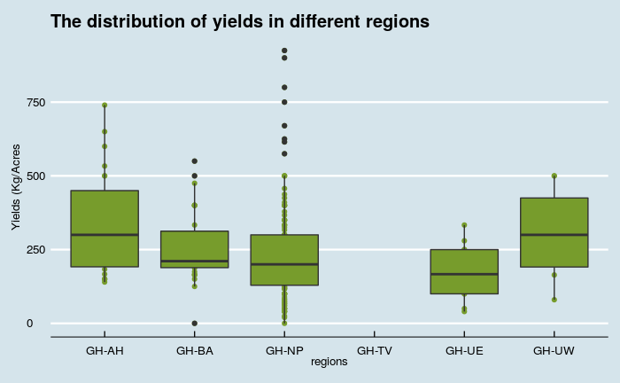

| region | district | cust_id.x | kg_acres |
| --- | --- | --- | --- |
| GH-AH | Ejura-Sekyedumase | 202802 | 200 |
| GH-AH | Ahafo Ano South | 206328 | NA |
| GH-AH | Ahafo Ano South | 206340 | NA |
| GH-AH | Ahafo Ano South | 206378 | NA |
| GH-AH | Ejura-Sekyedumase | 205665 | 400 |
| GH-AH | Ejura-Sekyedumase | 205154 | 150 |

The harvests (in yields/kg) shows that GH-AH and GH-UW are the best with GH-UW having a better harvest distribution as shown by the boxplot above. Additionally, GH-NP seems to have the greatest number of outliers. GH-UE has the worst harvest of all the other regions that were surveyed.

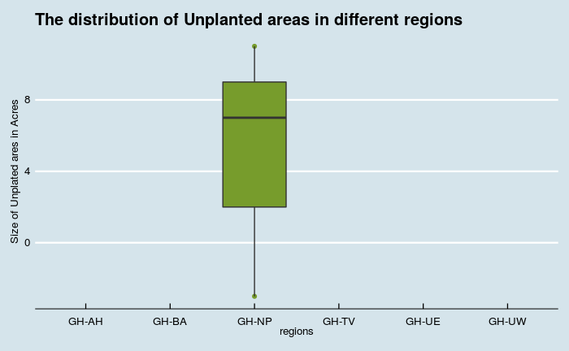

GH-NP is the only region where some farmers did not plant on the full farm with the median farm size left unplanted being 7 Acres. Additionally, there are is a farmer who underreported their farm size. This could be a case of data intergrity and is worthy of a closer look to determine the scale across WC database.

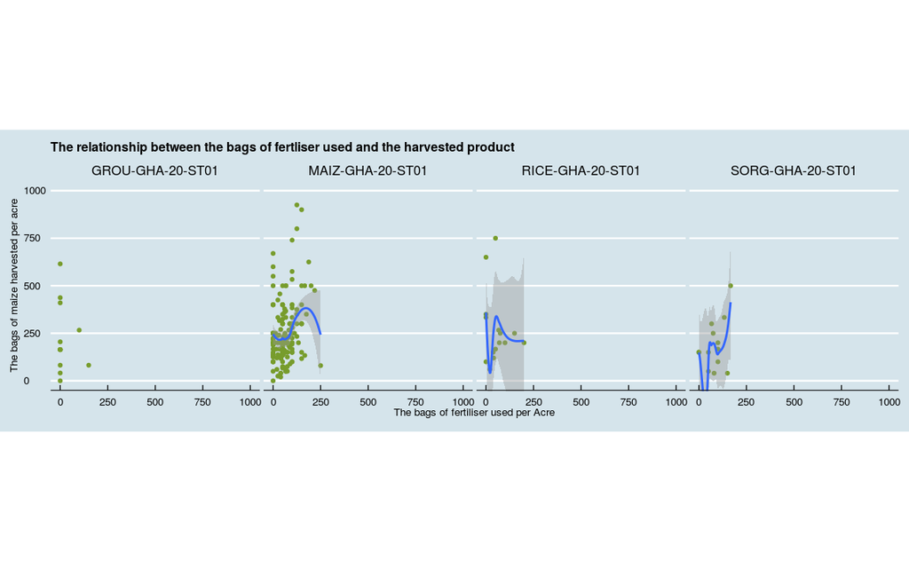

Fertiliser use (assuming 50kg is the standard bag of fertiliser) seems to influence the harvest proportion with the maximum rate being about 200kgs/acre. Of all the crops, Sorghum seems to respond the best to fertiliser application.

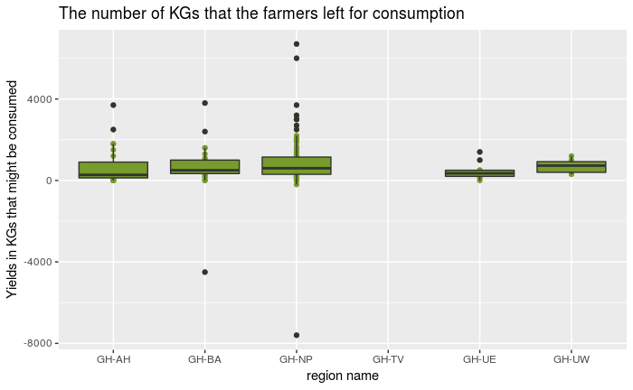

In GH-BA and GH-NP there are some farmers who seem to have misrepresented their harvest data. Investigation should reveal whether this deserves more attention or not.

Now that we have a better understanding of the harvest performace we can start to look at answering the questions posed.

### 1. Do crop yields (in kg/acre) vary significantly from region to region, from district to district, from farmer to farmer? What seems to be a normal, vs. low, vs. high yield for maize in Ghana?

#### Region to Region

```
Call:
lm(formula = kg_acres ~ region, data = surveysubset)

Residuals:
    Min      1Q  Median      3Q     Max
-256.00 -102.49  -35.83   69.81  689.17

Coefficients:
            Estimate Std. Error t value Pr(>|t|)
(Intercept)   338.33      33.87   9.988  < 2e-16 ***
regionGH-BA   -82.33      45.02  -1.829  0.06896 .
regionGH-NP  -102.51      36.73  -2.791  0.00577 **
regionGH-UE  -163.79      59.55  -2.750  0.00651 **
regionGH-UW   -32.83      66.68  -0.492  0.62299
---
Signif. codes:  0 ‘***’ 0.001 ‘**’ 0.01 ‘*’ 0.05 ‘.’ 0.1 ‘ ’ 1

Residual standard error: 162.5 on 198 degrees of freedom
  (125 observations deleted due to missingness)
Multiple R-squared:  0.05329,   Adjusted R-squared:  0.03416
F-statistic: 2.786 on 4 and 198 DF,  p-value: 0.02775
```

There’s some evidence of varying yields in all regions except GH-UW and across regions with a p-value of 0.02 we can assume variation of yields across regions. Our F-score at 2.7 confirms this as shown below.

```
Analysis of Variance Table

Response: kg_acres
           Df  Sum Sq Mean Sq F value  Pr(>F)
region      4  294127   73532  2.7862 0.02775 *
Residuals 198 5225586   26392
---
Signif. codes:  0 ‘***’ 0.001 ‘**’ 0.01 ‘*’ 0.05 ‘.’ 0.1 ‘ ’ 1
```

The anova test confirms this significant variation between groups in different regions.

#### District to District

```
Call:
lm(formula = kg_acres ~ district, data = surveysubset)

Residuals:
    Min      1Q  Median      3Q     Max
-237.92 -103.75  -16.67   56.95  726.11

Coefficients:
                             Estimate Std. Error t value Pr(>|t|)
(Intercept)                   291.204     55.292   5.267 4.13e-07 ***
districtBongo                -194.537    110.584  -1.759   0.0803 .
districtBunkpurugu Yonyo      -38.870     76.215  -0.510   0.6107
districtCentral Gonja         -92.316     74.556  -1.238   0.2173
districtChereponi              58.796    174.849   0.336   0.7371
districtEast Gonja            -18.426     87.424  -0.211   0.8333
districtEast Mamprusi         -73.426    110.584  -0.664   0.5076
districtEjura-Sekyedumase      47.130     65.219   0.723   0.4709
districtGushegu               -59.870     68.379  -0.876   0.3825
districtKaraga                -76.442     87.424  -0.874   0.3831
districtKassena Nankana West  -87.454     80.601  -1.085   0.2794
districtKpandai              -174.537    129.671  -1.346   0.1801
districtKumbungu              -66.918     83.594  -0.801   0.4245
districtMamprugo Moaduri      -41.204    110.584  -0.373   0.7099
districtMion                   21.225     92.521   0.229   0.8188
districtNandom                 21.596     92.521   0.233   0.8157
districtNanumba North        -149.870    110.584  -1.355   0.1771
districtNanumba South        -191.204    174.849  -1.094   0.2757
districtPru                   -74.537    110.584  -0.674   0.5012
districtSagnarigu             108.796    129.671   0.839   0.4026
districtSavelugu-Nanton       -28.288     63.293  -0.447   0.6555
districtSawla-Tuna-Kalba     -124.870     99.679  -1.253   0.2120
districtSene East             -80.815     73.144  -1.105   0.2708
districtSene West              22.884     87.424   0.262   0.7938
districtSissala West         -211.204    174.849  -1.208   0.2287
districtTamale Metropolitan    12.963     80.601   0.161   0.8724
districtTolon                -112.037     99.679  -1.124   0.2626
districtWa East               208.796    174.849   1.194   0.2341
districtWa West                 8.796    174.849   0.050   0.9599
districtWest Mamprusi        -141.204    174.849  -0.808   0.4205
districtYendi Municipal      -141.204     92.521  -1.526   0.1288
districtZabzugu              -110.704    110.584  -1.001   0.3182
---
Signif. codes:  0 ‘***’ 0.001 ‘**’ 0.01 ‘*’ 0.05 ‘.’ 0.1 ‘ ’ 1

Residual standard error: 165.9 on 171 degrees of freedom
  (125 observations deleted due to missingness)
Multiple R-squared:  0.1476,    Adjusted R-squared:  -0.006938
F-statistic: 0.9551 on 31 and 171 DF,  p-value: 0.5402

Analysis of Variance Table

Response: kg_acres
           Df  Sum Sq Mean Sq F value Pr(>F)
district   31  814668   26280  0.9551 0.5402
Residuals 171 4705044   27515
```

There’s little to no evidence in this data that confirm variation between the yields from one district to another. This is because we have an F-score less than 1 and a p-value greater than 0.05

#### Customer to Customer

```
Call:
lm(formula = kg_acres ~ cust_id.x, data = surveysubset)

Residuals:
    Min      1Q  Median      3Q     Max
-257.09 -110.22  -46.99   87.02  686.92

Coefficients:
             Estimate Std. Error t value Pr(>|t|)
(Intercept) 2.107e+02  2.868e+01   7.347 4.98e-12 ***
cust_id.x   2.461e-04  1.652e-04   1.490    0.138
---
Signif. codes:  0 ‘***’ 0.001 ‘**’ 0.01 ‘*’ 0.05 ‘.’ 0.1 ‘ ’ 1

Residual standard error: 164.8 on 201 degrees of freedom
  (125 observations deleted due to missingness)
Multiple R-squared:  0.01092,   Adjusted R-squared:  0.006004
F-statistic:  2.22 on 1 and 201 DF,  p-value: 0.1378

Analysis of Variance Table

Response: kg_acres
           Df  Sum Sq Mean Sq F value Pr(>F)
cust_id.x   1   60303   60303  2.2202 0.1378
Residuals 201 5459410   27161
```

There’s no evidence of variation of yields from customer to customer that can be confirmed with this survey.

#### Normal vs High Yield vs Low Yield

```
  Tukey multiple comparisons of means
    95% family-wise confidence level

Fit: aov(formula = kg_acres ~ region, data = surveysubset)

$region
                  diff        lwr         upr     p adj
GH-BA-GH-AH  -82.33254 -206.28839  41.6233152 0.3600739
GH-NP-GH-AH -102.50734 -203.62207  -1.3925998 0.0451625
GH-UE-GH-AH -163.78788 -327.74597   0.1702123 0.0503819
GH-UW-GH-AH  -32.83333 -216.41343 150.7467619 0.9880011
GH-NP-GH-BA  -20.17480 -110.70017  70.3505764 0.9728159
GH-UE-GH-BA  -81.45534 -239.10339  76.1927148 0.6139183
GH-UW-GH-BA   49.49921 -128.46794 227.4663512 0.9400952
GH-UE-GH-NP  -61.28054 -201.68013  79.1190458 0.7504448
GH-UW-GH-NP   69.67400  -93.21074 232.5587478 0.7641701
GH-UW-GH-UE  130.95455  -76.86631 338.7753969 0.4150850
```

### 2. Do other factors seem to influence crop yields, such as a farmer’s gender, literacy, phone ownership, farm size, use of fertilizer, proximity to a larger town, etc.?

```
Call:
lm(formula = kg_acres ~ ., data = yieldfactors)

Residuals:
    Min      1Q  Median      3Q     Max
-511.84  -88.77  -31.83   80.36  663.58

Coefficients: (1 not defined because of singularities)
                       Estimate Std. Error t value Pr(>|t|)
(Intercept)           1.068e+03  9.281e+02   1.151 0.251970
cust_id.x             1.675e-04  3.842e-04   0.436 0.663676
fert_bags             8.087e+00  2.077e+00   3.895 0.000163 ***
genderM               6.070e+00  3.479e+01   0.174 0.861777
literacynone          2.429e+01  8.770e+01   0.277 0.782268
farm_size            -5.099e-01  2.209e+01  -0.023 0.981619
num_parcels          -3.072e+01  1.375e+02  -0.223 0.823578
cht_seasonY2017S1     1.995e+00  9.801e+01   0.020 0.983791
cht_seasonY2018S1    -2.019e+01  1.060e+02  -0.190 0.849285
cht_seasonY2018S2     1.412e+02  1.428e+02   0.989 0.324837
cht_seasonY2019S1    -6.789e+00  1.365e+02  -0.050 0.960420
cht_seasonY2019S2     1.606e+02  1.608e+02   0.999 0.319774
cht_seasonY2020S1    -1.258e+02  2.872e+02  -0.438 0.662144
cht_channelUSSD      -5.823e+01  1.813e+02  -0.321 0.748601
cht_channelUSSD (CA) -8.605e+01  7.968e+01  -1.080 0.282383
cht_channelVISIT     -3.613e+01  7.681e+01  -0.470 0.638946
cht_channelZM/CA     -7.009e+01  9.977e+01  -0.703 0.483703
seasonY2019S2        -6.784e+01  6.829e+01  -0.993 0.322498
seasonY2020S1                NA         NA      NA       NA
typeCustomer         -8.258e+01  3.931e+01  -2.101 0.037745 *
loc_id               -9.564e-04  1.593e-02  -0.060 0.952216
has_mobile_moneyTRUE  2.996e+01  4.500e+01   0.666 0.506859
reg_nmGH-BA          -2.936e+02  2.808e+02  -1.046 0.297866
reg_nmGH-NP          -8.898e+02  9.175e+02  -0.970 0.334107
reg_nmGH-TV          -1.310e+02  1.894e+02  -0.692 0.490502
reg_nmGH-UE          -7.342e+02  9.230e+02  -0.795 0.427916
reg_nmGH-UW          -8.807e+02  9.112e+02  -0.967 0.335750
dist_id              -2.566e-01  2.267e-01  -1.132 0.260106
---
Signif. codes:  0 ‘***’ 0.001 ‘**’ 0.01 ‘*’ 0.05 ‘.’ 0.1 ‘ ’ 1

Residual standard error: 171.4 on 119 degrees of freedom
  (182 observations deleted due to missingness)
Multiple R-squared:  0.2549,    Adjusted R-squared:  0.09206
F-statistic: 1.565 on 26 and 119 DF,  p-value: 0.0557
```

The linear regression model above shoes that fertiliser bags and type have the most significance to the yields per kgs. Other factors have very low influence if any at all.

### 3. Out of the survey sample (cryield table), what is the proportion of farmers who reported bad/good crop yields and received (or did not receive) an insurance payout?

```
Chi-squared approximation may be incorrect
```

```
    Pearson's Chi-squared test

data:  payoutsselect
X-squared = 2935700, df = 654, p-value < 2.2e-16
```

### 4. At the district level, can we say that districts with poorer (or better) harvests received higher (or lower) insurance payout amounts?

```
Chi-squared approximation may be incorrect
```

```
    Pearson's Chi-squared test

data:  districtpayouts
X-squared = 380280, df = 654, p-value < 2.2e-16
```

The payouts across districts seem to have a correlation to the yields.

### 5. Can we trust the quality of our Y2019 sampled data?

```
    Two Sample t-test

data:  cryield$planted_acres and customers$farm_size
t = -11.653, df = 233, p-value < 2.2e-16
alternative hypothesis: true difference in means is not equal to 0
95 percent confidence interval:
 -9.323538 -6.626783
sample estimates:
mean of x mean of y
 4.358173 12.333333
```